# Ejercicio 6

Equipo

2024-03-26

## 6. Uso del modelo de regresión lineal simple.

A continuación se presentan los datos de los pesos de los huevos de 11 nidadas de pingüinos Macaroni, cada nidada tiene dos huevos, uno más pequeño (x) que el otro (y).

| x | 79 | 93 | 100 | 105 | 101 | 96 | 96 | 109 | 70 | 71 | 87 |
| --- | --- | --- | --- | --- | --- | --- | --- | --- | --- | --- | --- |
| y | 123 | 138 | 154 | 161 | 155 | 149 | 152 | 160 | 117 | 123 | 138 |

### I. Ajuste del modelo de regresión.

Ajustaremos una recta de regresión para estimar el peso promedio del huevo mayor (y) dado el peso del huevo menor (x), es decir, la variable dependiente es el peso del huevo más grande $y_i$ y la variable independiente es el peso del huevo menor.

$$y_i=\beta_0+\beta_1x_i+\varepsilon_i$$

La Gráfica siguiente muestra las observaciones y la recta ajustada, parece ser que hay un muy buen ajuste de la recta a los puntos.

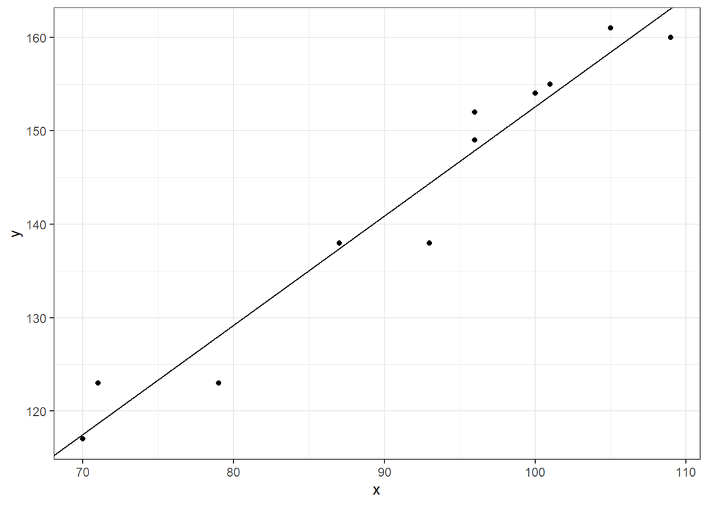

### III. Nueva observación (nidada). ¿Los huevos provienes de pinguinos Macaroni?

Se observa el peso de los huevos de una nueva nidada, observándose un peso de 70 y 145 gramos. Usando un intervalo de confianza del 95%, veremos si la nidada de huevos sí proviene de pinguinos Macaroni.

Al 95% de confianza, podemos predecir que el valor del huevo más grande debería estar entre el valor 112.5371035 y el valor 122.5270044 de acuerdo con un intervalo de confianza al rededor de la recta de regresión. El valor de 145 gramos no cae dentro del intervalo, por lo que podríamos concluir que la nueva observación no corresponde a los huevos de los pingüinos Macaroni, de acuerdo con el modelo planteado.En la siguiente Gráfica podemos observar este intervalo al rededor de la recta de regresión $\hat{y}_h \pm t_{\alpha / 2, n - 2} (s.e.)_y$ donde $(s.e.)_y = \sqrt{\frac{\sum^n_{i=1} (y_i - \hat{y})^2}{n - 2}} \sqrt{\frac{1}{n} + \frac{(x - \bar{x})^2}{\sum^n_{i=1} (x_i - \bar{x})^2}}$.

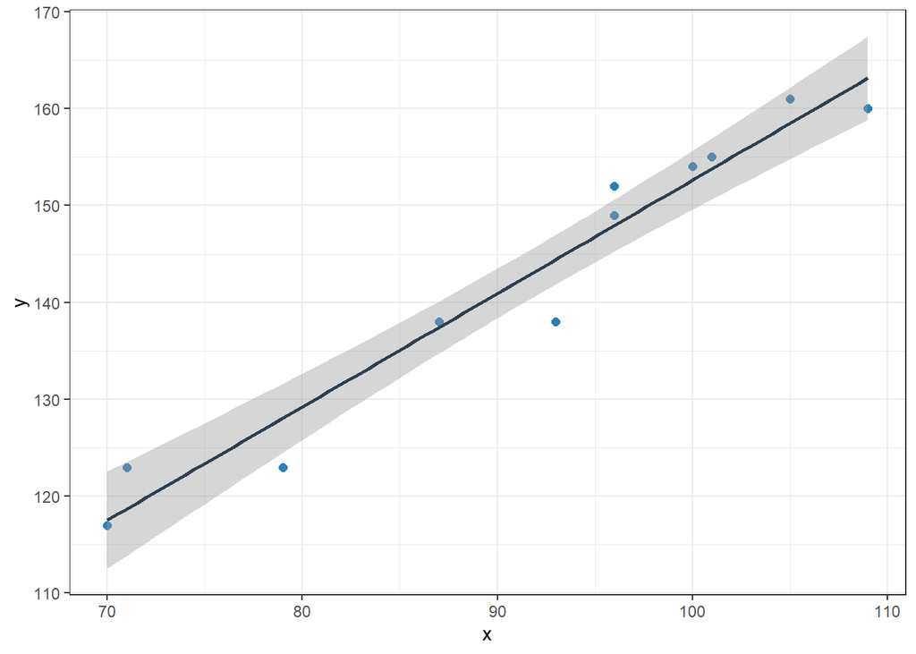